# HW5 Po-Chun Chen N11957611

All questions equal marks.

# Q1

Based on Aho textbook exercise 9.2, on page 414  
Parts a–d; e–f, but use the predict() function; part h, but use the predict() function; part i, but only 2 diagnotic plots, Residuals vs Fitted values, and Normal Q-Q plots.

### a. State the null and alternative hypotheses for the regression.

A: Null hypothesis: The slope is 0 which is $\beta$ is 0 Alternative hypothesis: The slope is not 0

### b. Run the regression using lm in R. Attach output.

```r
library(ggplot2)

weight.gain<- c(14.7, 17.8, 19.6, 18.4, 20.5, 21.1, 17.2, 18.7,20.2, 16.0, 17.8, 19.4)
lysine.eaten<- c(0.09, 0.14, 0.18, 0.15, 0.16, 0.23, 0.11, 0.19,0.23, 0.13, 0.17, 0.21)

weilys.lm<- lm(weight.gain ~lysine.eaten)
summary(weilys.lm)
```

```
##
## Call:
## lm(formula = weight.gain ~ lysine.eaten)
##
## Residuals:
##     Min      1Q  Median      3Q     Max
## -1.1662 -0.6741 -0.1367  0.5486  2.2590
##
## Coefficients:
##              Estimate Std. Error t value Pr(>|t|)
## (Intercept)    12.509      1.192   10.50 1.02e-06 ***
## lysine.eaten   35.828      6.957    5.15 0.000431 ***
## ---
## Signif. codes:  0 '***' 0.001 '**' 0.01 '*' 0.05 '.' 0.1 ' ' 1
##
## Residual standard error: 1.034 on 10 degrees of freedom
## Multiple R-squared:  0.7262, Adjusted R-squared:  0.6988
## F-statistic: 26.52 on 1 and 10 DF,  p-value: 0.0004315
```

### c. State your conclusions. Can we reject H0?

A small p-value(<0.001) for the intercept and the slope indicates that we can reject the null hypothesis which allows us to conclude that there is a relationship between weight.gain and lysine.eaten.

### d. Calculate the 90% CI for β1. Correctly summarize your results.

A: The $\beta$ can be calculated by the information provided in summary.lm().  
We can get the Estimate and Std. Error in summary.lm() to calculate the confidence interval by the following formula.

```r
c("lower" = 35.828 - qt(0.95, df = 10) * 6.957,
  "upper" = 35.828 + qt(0.95, df = 10) * 6.957)
```

```
##    lower    upper
## 23.21871 48.43729
```

### e. Calculate a 95% CI for E(Yh) by hand when Xh = 0.14. Correctly summarize your results. but use the predict() function

```r
CI_95 <- predict(weilys.lm, interval="confidence",level=0.95,data.frame(lysine.eaten=0.14))
print(CI_95)
```

```
##        fit     lwr      upr
## 1 17.52444 16.7481 18.30079
```

### f. Calculate a 95% PI for Yh(new) by hand when Xh = 0.14. Correctly summarize your results.

```r
PI_95 <- predict(weilys.lm, interval="prediction",level=0.95,data.frame(lysine.eaten=0.14))
print(PI_95)
```

```
##        fit     lwr      upr
## 1 17.52444 15.0932 19.95568
```

### g. Verify your results for (d), (e), and (f) using the functions confint and predict in R. Attach output.

```r
confint(weilys.lm,level = 0.95)
```

```
##                  2.5 %   97.5 %
## (Intercept)   9.853291 15.16376
## lysine.eaten 20.326963 51.32902
```

```r
summary(confint(weilys.lm,level = 0.95))
```

```
##      2.5 %            97.5 %
##  Min.   : 9.853   Min.   :15.16
##  1st Qu.:12.472   1st Qu.:24.21
##  Median :15.090   Median :33.25
##  Mean   :15.090   Mean   :33.25
##  3rd Qu.:17.709   3rd Qu.:42.29
##  Max.   :20.327   Max.   :51.33
```

### h. Create a plot of the regression. Overlay the confidence and prediction interval bands on the plot using plotCI.reg.

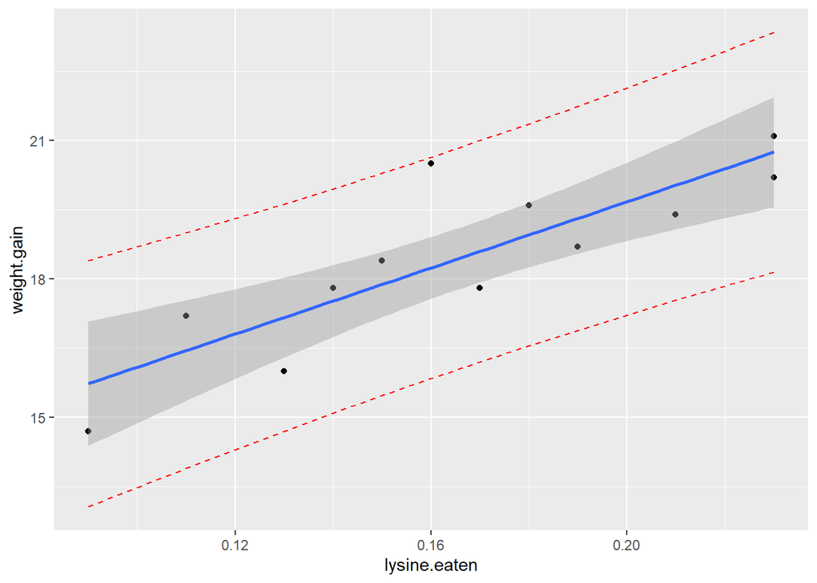

```r
#ggplot(data = combine, aes(y = weight.gain, x = lysine.eaten), level=0.95) +geom_point() + geom_smooth(method=lm, se=TRUE)
combine<- data.frame(weight.gain,lysine.eaten)
PI_95 <- predict(weilys.lm, interval="prediction",level=0.95)
new_combine <- cbind(combine, PI_95)
ggplot(new_combine, aes(y = weight.gain, x = lysine.eaten))+
  geom_point() +
  geom_line(aes(y=lwr), color = "red", linetype = "dashed")+
  geom_line(aes(y=upr), color = "red", linetype = "dashed")+
  geom_smooth(method=lm, se=TRUE)
```

### i. Create diagnostic plots for the regression and interpret them.

https://www.hackerearth.com/blog/developers/beginners-guide-regression-analysis-plot-interpretations/

A: Residual vs. Fitted Values Plot (Upper left)

Ideally, this plot shouldn’t show any pattern. But if you see any shape (curve, U shape), it suggests non-linearity in the data set. In addition, if you see a funnel shape pattern, it suggests your data is suffering from heteroskedasticity, i.e. the error terms have non-constant variance.

In our case, it shows linearity in the data set with most of the dot around the linear line.

Normality Q-Q Plot (Upper right)

As the name suggests, this plot is used to determine the normal distribution of errors. It uses standardized values of residuals. Ideally, this plot should show a straight line. If you find a curved, distorted line, then your residuals have a non-normal distribution (problematic situation).

In our case, it also shows a quite linear line which suggests that it is a normal distribution.

Scale Location Plot (Lower left)

This plot is also useful to determine heteroskedasticity. Ideally, this plot shouldn’t show any pattern. Presence of a pattern determine heteroskedasticity. Don’t forget to corroborate the findings of this plot with the funnel shape in residual vs. fitted values.

In our case, it also shows a linear line which suggests that it do not present a heteroskedasticity (Heteroscedasticity is a problem because ordinary least squares (OLS) regression assumes that all residuals are drawn from a population that has a constant variance).

Residuals vs. Leverage plots (Lower right)

The Residuals vs. Leverage plots helps you identify influential data points on your model. Outliers can be influential, though they don’t necessarily have to it and some points within a normal range in your model could be very influential.

In our case, there is not a outlier present.

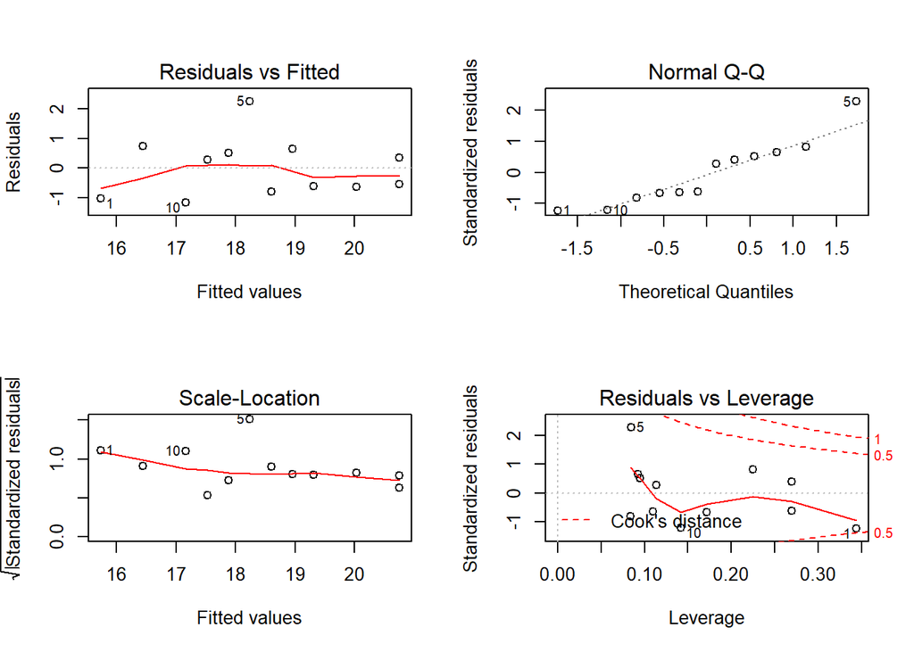

```r
par(mfrow=(c(2,2)))
plot(weilys.lm)
```

# Q2

Aho textbook exercise 9.8, on pages 415–416. The asbio data frame montane.island.txt is attached to this assignment, for those who can’t successfuly install the asbio package on their machines.

Among other things the theory of island biogeography* predicts that species richness will increase with increasing island area. Islands, however, need not be a bodyof land in water. Lomolino et al. (1989) investigated the relationship between the area of montane* forest patches (islands) and the richness of mammal fauna in the Southwestern United States. His data are contained in the asbio data object montane. island Regress species richness (number of species) as a function of island.

### a. Create a plot to examine the number of species as a function of island area.

```r
library(asbio)
```

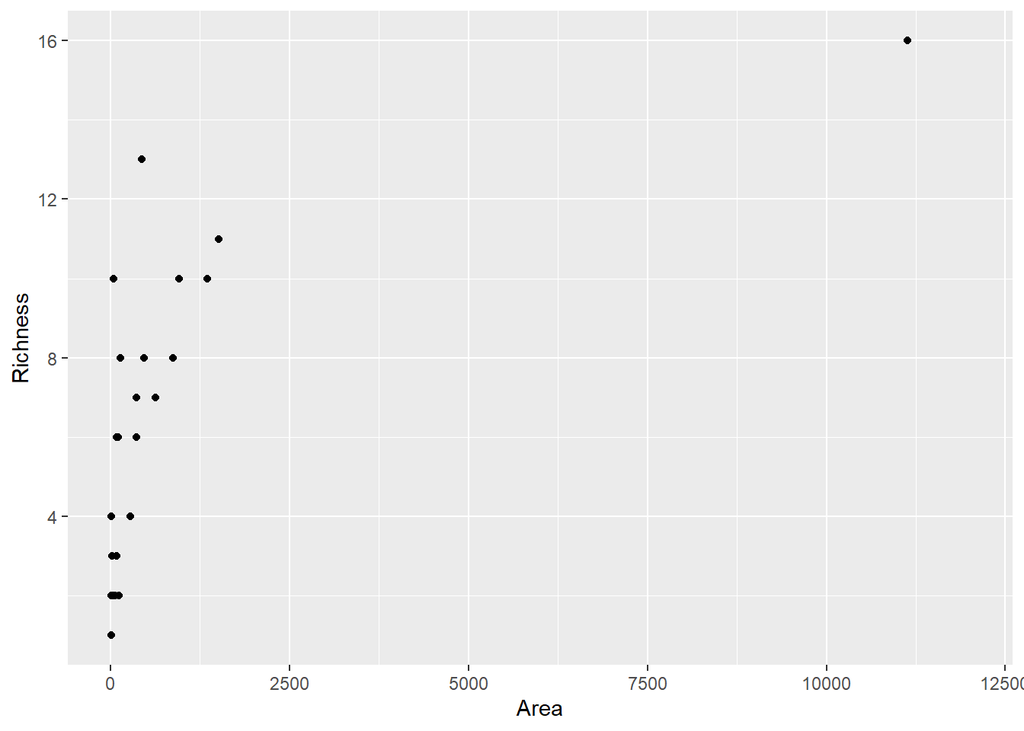

```r
library(tcltk)
library(ggplot2)
data("montane.island")
Species.lm<-lm(montane.island$Richness~montane.island$Area)
ggplot(data = montane.island, aes(y = Richness, x = Area))  +geom_point()+ scale_x_continuous(limits = c(0, 12000))
```

### b. A common transformation used when measuring the linear association of richness as a function of area is the log transformation of both X and Y variables (Begon et al. 1996). Perform this transformation and examine a scatterplot of the association.

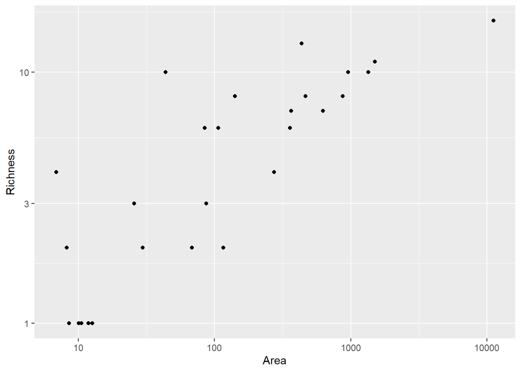

```r
ggplot(data = montane.island, aes(y = Richness, x = Area))+ geom_point() + scale_x_log10() + scale_y_log10()
```

### c. Does the transformed data appear suitable for linear regression? Why or why not?

A: By examining the new log transformed data. The p-value is quite low in our case which suggest there is a linearity. Therefore, the relationship between two variables may be linear.

In these cases we can sometimes see strange and even inscrutable patterns in a scatterplot of the data. Sometimes there really is no meaningful relationship between the two variables. Other times, a careful transformation of one or both of the variables can reveal a clear relationship.

```r
Species.lm_new<-lm(log(montane.island$Richness)~log(montane.island$Area))
summary(Species.lm_new)
```

```
##
## Call:
## lm(formula = log(montane.island$Richness) ~ log(montane.island$Area))
##
## Residuals:
##      Min       1Q   Median       3Q      Max
## -0.72376 -0.40382 -0.05562  0.26758  1.25504
##
## Coefficients:
##                          Estimate Std. Error t value Pr(>|t|)
## (Intercept)              -0.39052    0.25889  -1.508    0.144
## log(montane.island$Area)  0.38036    0.05079   7.489 7.67e-08 ***
## ---
## Signif. codes:  0 '***' 0.001 '**' 0.01 '*' 0.05 '.' 0.1 ' ' 1
##
## Residual standard error: 0.5102 on 25 degrees of freedom
## Multiple R-squared:  0.6917, Adjusted R-squared:  0.6793
## F-statistic: 56.08 on 1 and 25 DF,  p-value: 7.667e-08
```

### d. Perform a linear regression using the transformed data.

```r
library(ggplot2)
Species.trans.lm<- lm(formula = log(montane.island$Richness) ~ log(montane.island$Area))
summary(Species.trans.lm)
```

```
##
## Call:
## lm(formula = log(montane.island$Richness) ~ log(montane.island$Area))
##
## Residuals:
##      Min       1Q   Median       3Q      Max
## -0.72376 -0.40382 -0.05562  0.26758  1.25504
##
## Coefficients:
##                          Estimate Std. Error t value Pr(>|t|)
## (Intercept)              -0.39052    0.25889  -1.508    0.144
## log(montane.island$Area)  0.38036    0.05079   7.489 7.67e-08 ***
## ---
## Signif. codes:  0 '***' 0.001 '**' 0.01 '*' 0.05 '.' 0.1 ' ' 1
##
## Residual standard error: 0.5102 on 25 degrees of freedom
## Multiple R-squared:  0.6917, Adjusted R-squared:  0.6793
## F-statistic: 56.08 on 1 and 25 DF,  p-value: 7.667e-08
```

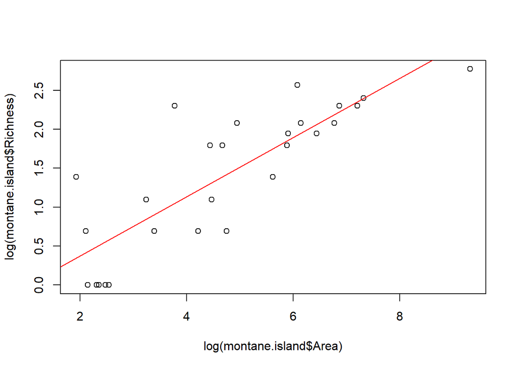

```r
plot(log(montane.island$Area),log(montane.island$Richness))
abline(lm(log(montane.island$Richness) ~ log(montane.island$Area), data = montane.island), col = "red")
```

### e. Preston (1962) described the following relationship:S = CA^γ where S is the number of species, A is the island area, C is a constant describing the number of species when A = 1, and γ is a biologically meaningful parameter describing a particular group of organisms, for example, flowering plants, birds, and zooplankton (Begon et al. 1996). In particular, the quantity γ represents the number of species that would be lost given the destruction of their habitat. Use the slope of the simple linear regression model log(S) = log(A)g to estimate γ (Ramsey and Schafer 1997). Assuming that the sampling distribution of γ is normally distributed calculate a 95% confidence interval for γ.

```r
c("lower" = 0.38036 - qt(0.975, df = 25) * 0.05079,
  "upper" = 0.38036 + qt(0.975, df = 25) * 0.05079)
```

```
##    lower    upper
## 0.275756 0.484964
```

# 3.

The following code shows a function that uses a Monte-Carlo simulation to calculate the posterior probability interpretation of p-values near 0.05 for differing prior probabilities/plausibilities of the null hypothesis.

Use this function to plot a graph of posterior probability versus prior probability from 0.1 to 0.9.

```r
# This function simulates a one-sample experimental design.
# It generates a set of experimental results where the effect is real
# and a set of experimental results where the null hypothesis is true.
# Arguments: prior=prior probability that the null is true
# Returns: posterior probability that null is true for p-values near 0.05
pvalue_monte_carlo <- function(prior)
{
# The power of the experiment affects the interpretation of the p-value. We set some example values here.
n <- 10   # sample size
sigma <- 20.0 # population standard deviation
effect_size <- 20.0 # size of effect of experimental treatment

x <- 0
y <- 0
no_effect <- c()
effect <- c()

for (i in 1:100000) {
  isnull <- sample(c(TRUE,FALSE), 1, prob=c(prior, 1-prior)) # randomly choose either a null or active treatment depending on prior
  if (isnull == TRUE) {     # if treatment has no effect (null is true)
    exp <- rnorm(n, mean=120.0,sd = sigma)
  } else {                  # # if treatment has an effect
    exp <- rnorm(n, mean=120.0-effect_size,sd = sigma)
  }
  pval <- t.test(exp, mu=120)$p.value # one-sample t-test
  if (isnull == TRUE) {     # if treatment has no effect (null is true)
    no_effect[i] <- pval
  } else {
    effect[i] <- pval
  }
  if (pval < 0.05 && pval >= 0.049) {  # choose p-values near some value
    x <- x + 1              # count how many such p-values there are
    if (isnull == TRUE) {
      y <- y + 1            # of these p-values, for how many was the null hypothesis true
    }
  }
}
return(y/x)
}
```

```r
number<-1
sequence<-seq(from=0.1, to=0.9, by=0.1)
priority_probability<-rep(0,9)
for (i in sequence){
    priority_probability[number]<-pvalue_monte_carlo(i)
    #print(i)
    number<-number+1
    #print(number)
}

print("This is the posterior probability")
```

```
## [1] "This is the posterior probability"
```

```r
print(priority_probability)
```

```
## [1] 0.03806228 0.10320285 0.11188811 0.20083682 0.23943662 0.32142857
## [7] 0.41317365 0.48611111 0.83464567
```

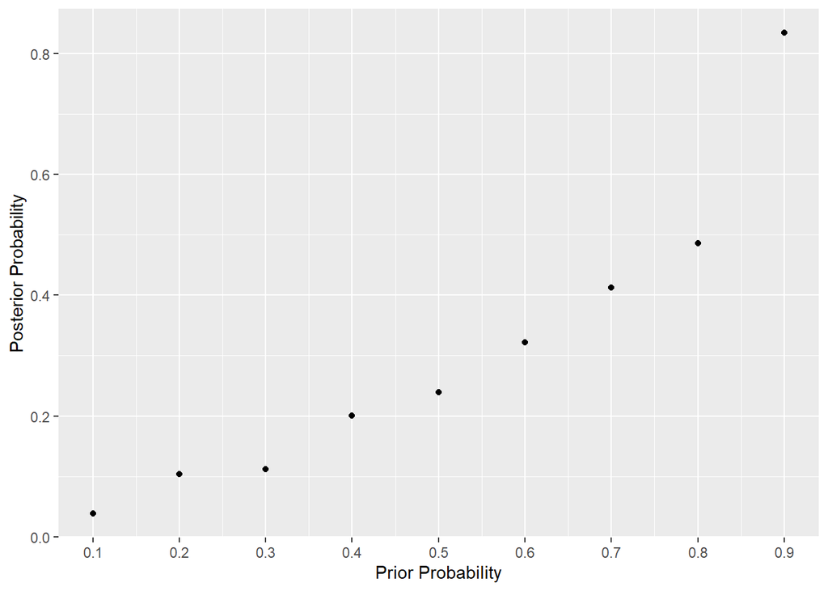

```r
combine_pvalue<- data.frame(sequence,priority_probability)
ggplot(data = combine_pvalue, aes(y = priority_probability, x = sequence)) +geom_point() +xlab("Prior Probability") + ylab("Posterior Probability")+ scale_x_continuous(breaks=seq(0.1, 0.9, 0.1))
```

# 4

The following code shows a function that uses a Monte-Carlo simulation to return the power of a one-sample t-test.

Add comments describing how the code functions.

Assume that if the drug has an effect size of 20.0 mmHg, then we want a p-value of 0.005 for 80% across replications of the experiment. The population standard deviation is 20 mmHg.

Use this function to plot a graph of power versus sample size from 2 to 20. What sample size do you suggest for this experiment?

Use the power.t.test() function for the power analysis. How does its recommendation compare to the Monte Carlo simulation?

Add comments describing how the code functions.

```r
# Monte Carlo simulation of power of one sample z-test
# arguments: sample_size=n, effect_size=delta, sigma=sd, type1_error=sig.level
# returns: power
power_monte_carlo <- function(sample_size, effect_size, sigma, type1_error_rate) #input the parameter to calculate the power
{
  pval <- c() #use a vector to store p value
  num_iter <- 10000 # number of iterations for monte_carlo simulation
  for (i in 1:num_iter) {
    exp <- rnorm(sample_size, mean=effect_size,sd = sigma) # use rnorm to create a data with mean = effect_size and sd = sigma
    pval[i] <- t.test(exp, mu=0)$p.value # one-sample t-test and extract the p-value for the t-test
  }
  type2_error_rate <- sum(pval >= type1_error_rate)/num_iter # type2_error_rate means the probability of failing to   reject a false null hypothesis which means p_value larger than the predefined alpha= 0.005
  return(1-type2_error_rate) # power = 1-type2_error_rate
}
```

Use this function to plot a graph of power versus sample size from 2 to 20. What sample size do you suggest for this experiment?

A: The power the larger the better. I would say I suggest 20 in our case and larger than 18 at least to meet the 80% requirement.

```r
library(ggplot2)
number<-1
effect_size<-20
type1_error_rate<-0.005
sigma<-20
sample_size<-seq(from=2, to=20, by=1)
power<-rep(0,19)
for (i in sample_size){
  power[number]<-power_monte_carlo(i,effect_size = effect_size,sigma = sigma,type1_error_rate = type1_error_rate)
  #print(i)
  number<-number+1
  #print(number)
}

print(power)
```

```
##  [1] 0.0101 0.0208 0.0414 0.0750 0.1144 0.1693 0.2355 0.3095 0.3774 0.4520
## [11] 0.5246 0.5811 0.6450 0.6869 0.7433 0.7904 0.8275 0.8536 0.8818
```

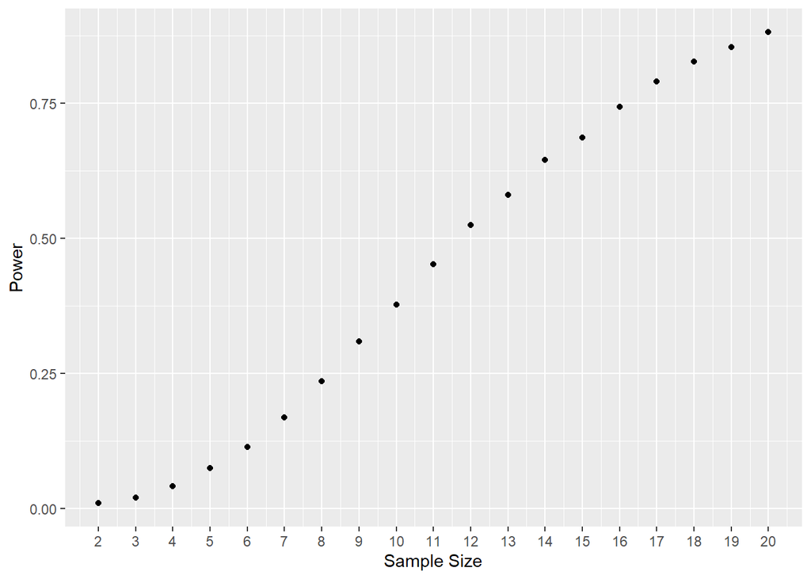

```r
combine_power<- data.frame(sample_size,power)
ggplot(data = combine_power, aes(y = power, x = sample_size)) +geom_point() +xlab("Sample Size") + ylab("Power")+ scale_x_continuous(breaks=seq(2, 20, 1))
```

Use the power.t.test() function for the power analysis. How does its recommendation compare to the Monte Carlo simulation?

A: The power values calculated by both methods are almost the same.

```r
power.t.test(sample_size,sd=20,sig.level = 0.005,type="one.sample",delta = 20)
```

```
##
##      One-sample t test power calculation
##
##               n = 2, 3, 4, 5, 6, 7, 8, 9, 10, 11, 12, 13, 14, 15, 16, 17, 18, 19, 20
##           delta = 20
##              sd = 20
##       sig.level = 0.005
##           power = 0.009084683, 0.019714849, 0.039935416, 0.072170477, 0.116728260, 0.172182922, 0.236031245, 0.305309848, 0.377062966, 0.448646439, 0.517891462, 0.583162676, 0.643344508, 0.697784264, 0.746213751, 0.788664736, 0.825388158, 0.856782725, 0.883335515
##     alternative = two.sided
```

```r
power.t.test(delta=20, sd=20, sig.level=0.005,power=0.8, alternative="two.sided",type ="one.sample")
```

```
##
##      One-sample t test power calculation
##
##               n = 17.29294
##           delta = 20
##              sd = 20
##       sig.level = 0.005
##           power = 0.8
##     alternative = two.sided
```

```r
number<-1
effect_size<-20
type1_error_rate<-0.005
sigma<-20
sample_size<-seq(from=2, to=80, by=1)
power<-rep(0,79)
for (i in sample_size){
  power[number]<-power_monte_carlo(i,effect_size = effect_size,sigma = sigma,type1_error_rate = type1_error_rate)
  #print(i)
  number<-number+1
  #print(number)
}

print(power)
```

```
##  [1] 0.0093 0.0208 0.0425 0.0710 0.1168 0.1691 0.2401 0.3026 0.3824 0.4546
## [11] 0.5175 0.5788 0.6426 0.6982 0.7418 0.7842 0.8261 0.8541 0.8828 0.9018
## [21] 0.9236 0.9405 0.9504 0.9603 0.9703 0.9752 0.9829 0.9856 0.9889 0.9907
## [31] 0.9922 0.9961 0.9957 0.9968 0.9971 0.9993 0.9987 0.9994 0.9995 0.9994
## [41] 0.9997 0.9996 0.9999 1.0000 0.9999 0.9996 0.9998 1.0000 1.0000 1.0000
## [51] 1.0000 0.9999 1.0000 1.0000 1.0000 1.0000 1.0000 1.0000 1.0000 1.0000
## [61] 1.0000 1.0000 1.0000 1.0000 1.0000 1.0000 1.0000 1.0000 1.0000 1.0000
## [71] 1.0000 1.0000 1.0000 1.0000 1.0000 1.0000 1.0000 1.0000 1.0000
```

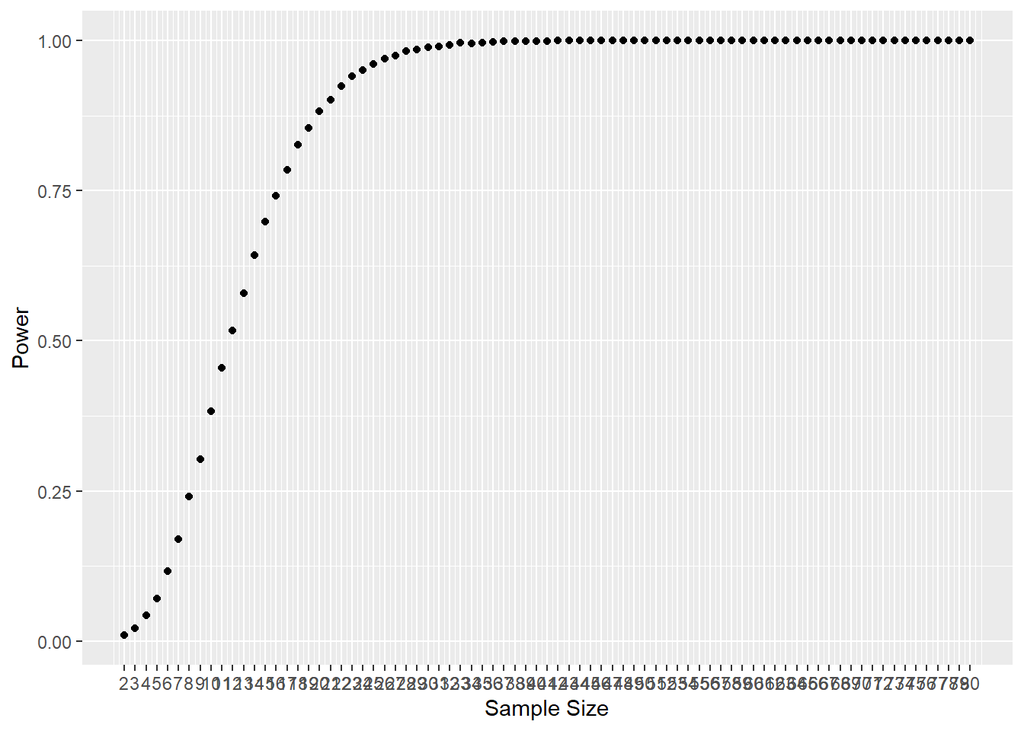

```r
combine_power<- data.frame(sample_size,power)
ggplot(data = combine_power, aes(y = power, x = sample_size)) +geom_point() +xlab("Sample Size") + ylab("Power")+ scale_x_continuous(breaks=seq(2, 80, 1))
```